# Reformat and process proteomics

Sara Gosline

2025-09-28

## Normalize phospho-proteomics

We now have phospho proteomics from two cohorts. Here I’m trying to collect data from both and normalize but am clearly missing something. I do the following:

1. replace all zero values with NA to avoid skewing normalization
2. remove any features that are absent from >50% of the samples
3. take the log of the data, then take a modified z score

Each dataset is done individually then combined at the end. There is a clear batch effect.

### Cohort 1 phospho

We start with the cohort 1 phospho data here.

```r
##cohort 1 phospho
##first we read in file, and get site info
phospho1<- read.table(syn$get('syn69963552')$path,sep='\t',fill=NA,header=T,quote='"') |>
  subset(!is.na(`Gene.Names`)) |>
  subset(Gene.Names!='') |>
  mutate(lsite=tolower(Residue)) |>
  tidyr::unite(c(Residue,Site,lsite),col='site',sep='') |>
  tidyr::unite(c(`Gene.Names`,site),col='site',sep='-') |>
  as.data.frame()

phospho1[which(phospho1==0,arr.ind=TRUE)]<-NA

pfnames1 <- data.frame(fname=colnames(phospho1)[5:ncol(phospho1)])|>
  mutate(aliquot=sapply(fname,function(x) unlist(strsplit(x,split='_'))[8]))|>
  mutate(aliquot=as.double(aliquot))|>
  mutate(cohort=1)

##logtransform##median transform
pzeros<-which(apply(phospho1[,5:ncol(phospho1)],1,function(x)
    length(which(is.na(x)))/length(x) < 0.5))

pmat1<-apply(0.01+log2(phospho1[pzeros,5:ncol(phospho1)]),2,
             function(x) {0.6745 *(x-median(x,na.rm=T))/mad(x,na.rm=T)}) |>
  as.data.frame() |>
  mutate(site=phospho1$site[pzeros])

##move to long form, upload
plong1<-pmat1|>
  tidyr::pivot_longer(1:(ncol(pmat1)-1),names_to='fname',values_to='abundance')|>
  left_join(pfnames1) |>
  group_by(site,fname,aliquot,cohort) |>
  summarize(meanAbundance=mean(abundance,na.rm=T))|>
  subset(!is.na(meanAbundance))|>
  left_join(meta)
readr::write_csv(plong1,file='log2normMedCenteredPhospho.csv')
syn$store(File('log2normMedCenteredPhospho.csv',parentId='syn70078365'))
```

```
## File(id='syn65598472', synapseStore=True, modifiedOn='2025-10-07T16:10:10.287Z', dataFileHandleId='163828412', versionNumber=51, name='log2normMedCenteredPhospho.csv', createdBy='1418096', parentId='syn70078365', path='log2normMedCenteredPhospho.csv', _file_handle={'id': '163828412', 'etag': 'c53…
```

The file is uploaded to synapse.

### Cohort 2 phospho

Now on October 7 we can process the second batch of phospho.

```r
##cohort 2 phospho
##1 read in data
phospho2 <- read.table(syn$get('syn69947351')$path,sep='\t',fill=NA,header=T,quote='"') |>
  subset(!is.na(`Gene.Names`)) |>
  subset(Gene.Names!='') |>
  mutate(lsite=tolower(Residue)) |>
  tidyr::unite(c(Residue,Site,lsite),col='site',sep='') |>
  tidyr::unite(c(`Gene.Names`,site),col='site',sep='-')


phospho2[which(phospho2==0,arr.ind=TRUE)] <- NA

pfnames2 <- data.frame(fname=colnames(phospho2)[5:ncol(phospho2)]) |>
  mutate(aliquot=sapply(fname,function(x) unlist(strsplit(x,split='_'))[9])) |>
  mutate(aliquot=as.double(aliquot))|>
  mutate(cohort=2)

##remove missingness
tm <- which(apply(phospho2[,5:ncol(phospho2)],1,function(x) length(which(is.na(x)))/length(x) < 0.5))

##log2 adjusted z score
pmat2<-apply(log2(0.01+phospho2[tm,5:ncol(phospho2)]),2,
              function(x) {0.6745 *(x-median(x,na.rm=T))/mad(x,na.rm=T)}) |>
  as.data.frame() |>
  mutate(site=phospho2$site[tm])



plong2<-pmat2|>
  tidyr::pivot_longer(1:(ncol(pmat2)-1),names_to='fname',values_to='abundance') |>
  left_join(pfnames2)|>
  group_by(site,fname,aliquot,cohort) |>
  summarize(meanAbundance=mean(abundance,na.rm=T)) |>
  subset(!is.na(meanAbundance))|>
  left_join(meta)
##save to file
readr::write_csv(plong2,file='log2normMedCenteredPhospho_cohort2.csv')
syn$store(File('log2normMedCenteredPhospho_cohort2.csv',parentId='syn70078365'))
```

```
## File(synapseStore=True, id='syn70078413', path='log2normMedCenteredPhospho_cohort2.csv', createdOn='2025-10-07T15:56:04.262Z', createdBy='1418096', files=['log2normMedCenteredPhospho_cohort2.csv'], _file_handle={'id': '163828418', 'etag': '1d896b0a-e1eb-4083-a6e0-b3f266dc59ce', 'createdBy': '1418…
```

Now that we have two cohorts we can try to combine without batch correction.

### Combined phospho

Combining the phoshpo data here.

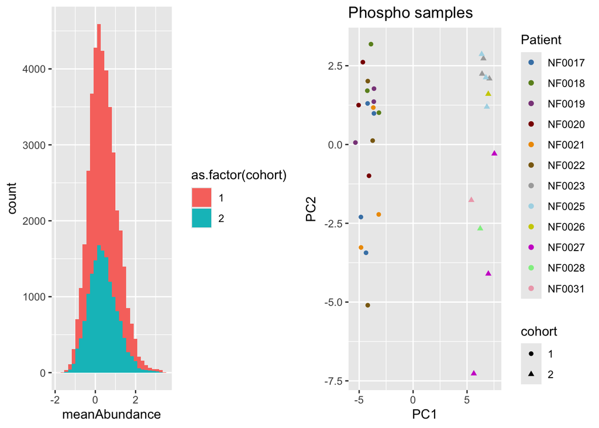

```r
##now we move back to long form
plong <- rbind(plong1,plong2)
  #pmat |>
#  as.data.frame()|>
#  tibble::rownames_to_column('site')|>
#  pivot_longer(-site,names_to='fname',values_to='abundance')|>
#  left_join(rbind(pfnames1,pfnames2))|>
#    group_by(site,fname,aliquot,cohort) |>
#  summarize(meanAbundance=mean(abundance,na.rm=T)) |>
#  left_join(meta)


compsites <- plong|>
#  subset(meanAbundance>(-5))|>
  group_by(site)|>
  summarize(spec = n_distinct(Specimen))|>
  subset(spec==31)

#plong$meanAbundance[which(!is.finite(plong$meanAbundance))]<-0

ppcs<-plong|>ungroup()|>
  dplyr::select(Specimen,meanAbundance,site)|>
  unique()|>
  subset(site%in%compsites$site)|>
  #subset(!is.na(site))|>
  #subset(!is.na(meanAbundance))|>
  tidyr::pivot_wider(names_from='Specimen',values_from='meanAbundance',
                     values_fn=mean,values_fill=0)|>
  tibble::column_to_rownames('site')|>
  t()|>
  prcomp()

pplot<-ppcs$x|>
  as.data.frame()|>
  dplyr::select(PC1,PC2,PC3)|>
  tibble::rownames_to_column('Specimen')|>
  left_join(meta)|>
  dplyr::select(PC2,PC1,Specimen,Patient,cohort)|>
  mutate(cohort=as.factor(cohort))|>
  distinct()|>
  ggplot(aes(x=PC1,y=PC2,label=Specimen,col=Patient,shape=cohort))+
    geom_point()+
    #ggrepel::geom_label_repel()+
    ggtitle("Phospho samples")+
  ggplot2::scale_color_manual(values=pcols)
ph<- plong |>ungroup()|>
  subset(site%in%compsites$site)|>
  ggplot(aes(x=meanAbundance,fill=as.factor(cohort)))+geom_histogram()

cowplot::plot_grid(ph,pplot)
```

```r
ggsave('cNFPhosphoQC.png',width=10)
```

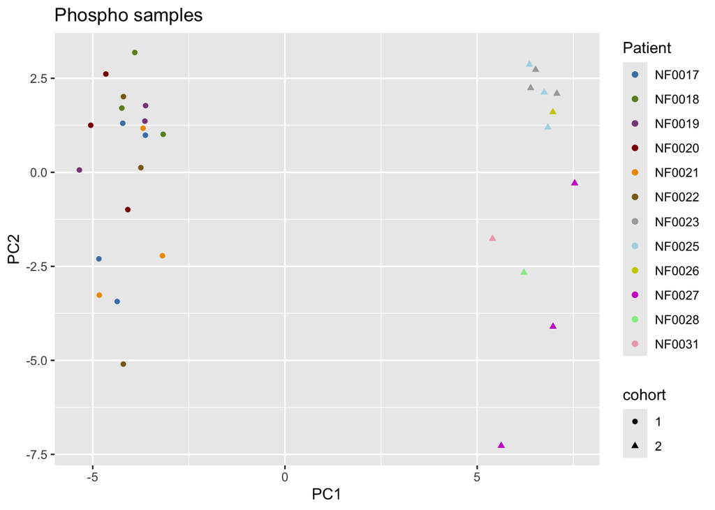

```r
pplot
```

```r
ggsave('phosphoPCA.pdf')
```

Clearly there is a strong batch effect.

## Normalize golbal proteomics

Now we can move onto the global data

### Cohort 1 global

Global proteomics in cohort 1 here.

```r
####now process global
#global1<-readr::read_tsv(syn$get('syn64906445')$path)
global1 <- read.table(syn$get('syn69947355')$path,sep='\t',header=T,quote='"') |>
  tidyr::separate_rows(Genes,sep=';')
##logtransform, medina transform

#global1[which(global1==0,arr.ind=TRUE)]<-NA

gmat1<-apply(log2(global1[,5:ncol(global1)]),2,function(x) 0.6745 *(x-median(x,na.rm=T))/mad(x,na.rm=T))

gmat1<-gmat1|>
  as.data.frame()|>
  mutate(Genes=global1$Genes)

##extract aliquot info from file name
gfnames1 <- data.frame(fname=colnames(global1)[5:ncol(global1)]) |>
  mutate(aliquot=sapply(fname,function(x) unlist(strsplit(x,split='_'))[6])) |>
  mutate(aliquot=as.double(aliquot))|>
  mutate(cohort=1)

glong1<-gmat1|>
    tidyr::pivot_longer(1:(ncol(gmat1)-1),names_to='fname',values_to='abundance')|>
 left_join(gfnames1)|>
   group_by(Genes,fname,aliquot,cohort)|>
  summarize(meanAbundance=mean(abundance))|>
  subset(is.finite(meanAbundance))|>
  left_join(meta)
readr::write_csv(glong1,file='log2normMedCenteredGlobal.csv')
syn$store(File('log2normMedCenteredGlobal.csv',parentId='syn70078365'))
```

```
## File(files=['log2normMedCenteredGlobal.csv'], synapseStore=True, name='log2normMedCenteredGlobal.csv', _file_handle={'id': '163828754', 'etag': 'ecb596c9-4869-4413-9838-eb66cb83b76b', 'createdBy': '1418096', 'createdOn': '2025-10-02T02:09:54.000Z', 'modifiedOn': '2025-10-02T02:09:54.000Z', 'concr…
```

### Cohort 2 global

October 7 we process the second cohort.

```r
global2<-read.table(syn$get('syn69947352')$path,header=T,sep='\t',quote='"')|>
  tidyr::separate_rows(Genes,sep=';')

#global2[which(global2==0,arr.ind=TRUE)]<-NA

gmat2<-apply(log2(global2[,5:ncol(global2)]),2,function(x)
  0.6745 *(x-median(x,na.rm=T))/mad(x,na.rm=T))
rownames(gmat2)<-global2$Genes

gmat2<-gmat2|>
  as.data.frame()|>
  mutate(Genes=global2$Genes)

gfnames2 <- data.frame(fname=colnames(global2)[5:ncol(global2)]) |>
  mutate(aliquot=sapply(fname,function(x) unlist(strsplit(x,split='_'))[7])) |>
  mutate(aliquot=as.double(aliquot))|>
  mutate(cohort=2)

glong2<-gmat2|>
  tidyr::pivot_longer(1:(ncol(gmat2)-1),names_to='fname',values_to='abundance')|>
  left_join(gfnames2)|>
  group_by(Genes,fname,aliquot,cohort)|>
  summarize(meanAbundance=mean(abundance))|>
  subset(is.finite(meanAbundance))|>
  left_join(meta)
#dupes<-global|>group_by(Genes)|>summarize(numIso=n())|>
#  subset(numIso>1)


readr::write_csv(glong2,file='log2normMedCenteredGlobal_cohort2.csv')
syn$store(File('log2normMedCenteredGlobal_cohort2.csv',parentId='syn70078365'))
```

```
## File(synapseStore=True, files=['log2normMedCenteredGlobal_cohort2.csv'], createdBy='1418096', dataFileHandleId='163828776', createdOn='2025-10-07T15:56:09.318Z', parentId='syn70078365', modifiedOn='2025-10-07T16:10:16.010Z', name='log2normMedCenteredGlobal_cohort2.csv', etag='d11f86af-5af5-49f7-a…
```

### Global combined without batch correction

Now we can combine the global withot batch correction.

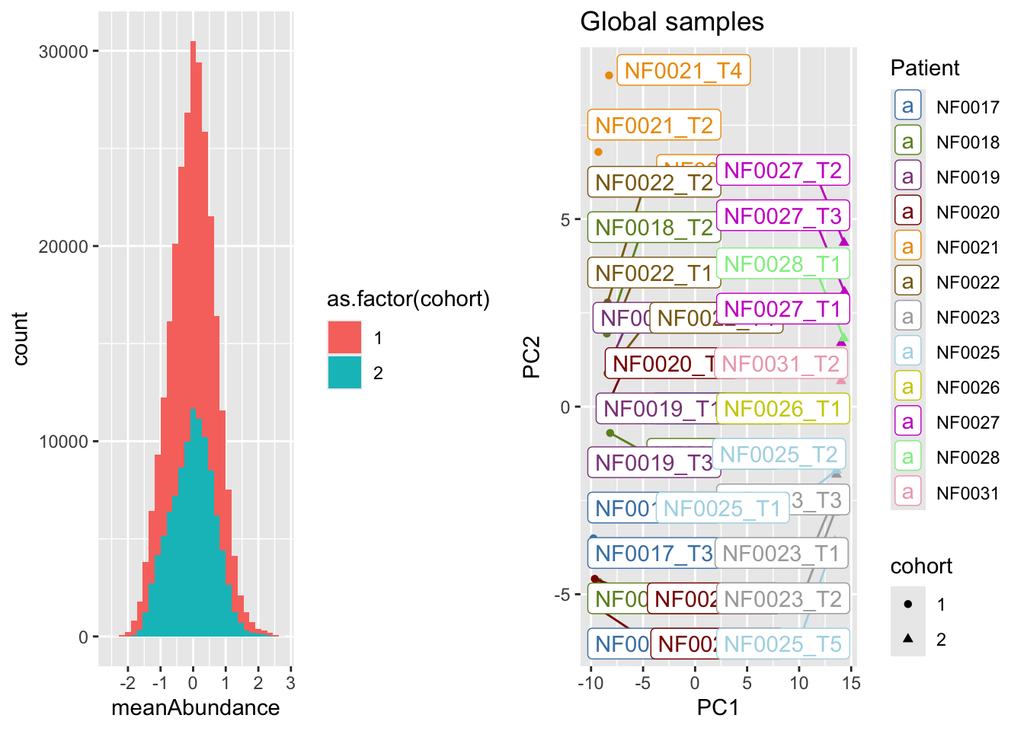

```r
#ma<-mean(glong$abundance,na.rm=T)
#glong$meanAbundance[which(!is.finite(glong$meanAbundance))]<-0
glong <- rbind(glong1,glong2)|>
  subset(Genes!="")

compsites <- glong|>
#  subset(meanAbundance>(-5))|>
  group_by(Genes)|>
  summarize(spec = n_distinct(Specimen))|>
  subset(spec==31)

gpcs<-glong|>ungroup()|>
  dplyr::select(Specimen,meanAbundance,Genes)|>
  subset(!is.na(Genes))|>
  subset(Genes!="")|>
  subset(Genes%in%compsites$Genes)|>
  subset(!is.na(meanAbundance))|>
  tidyr::pivot_wider(names_from='Specimen',values_from='meanAbundance',values_fn=mean,values_fill=0)|>
  tibble::column_to_rownames('Genes')|>t()|>
  prcomp()

gplot<-gpcs$x|>
  as.data.frame()|>
  dplyr::select(PC1,PC2)|>
  tibble::rownames_to_column('Specimen')|>
  left_join(meta)|>
    dplyr::select(PC1,PC2,Specimen,Patient,cohort)|>
    mutate(cohort=as.factor(cohort))|>
  distinct()|>
  ggplot(aes(x=PC1,y=PC2,label=Specimen,col=Patient,shape=cohort))+
  geom_point()+ggrepel::geom_label_repel()+ggtitle("Global samples")+
  scale_color_manual(values=pcols)
hplot <- ggplot(glong,aes(x=meanAbundance,fill=as.factor(cohort)))+geom_histogram()


cowplot::plot_grid(hplot,gplot)
```

```r
ggsave('cNFGlobalQC.png',width=10)
```

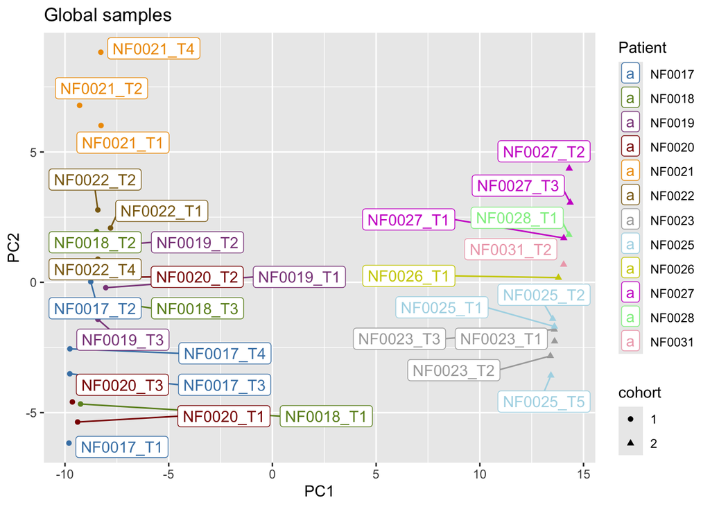

```r
gplot
```

```r
ggsave('globalPCA.pdf')
```

## Evaluate batch correction

Now we have two separate long tables with metadata, but we would like to combine into a single one and batch correct.We can update this with each cohort.

```r
##phospho
##TODO: ideally we should use the long tables and reconvert
pmat <- merge(as.data.frame(pmat1),as.data.frame(pmat2))

gmat <- merge(gmat1,gmat2)

##remove duplicated sites
dsites<- unique(pmat$site[which(duplicated(pmat$site))])
mvals<-sapply(dsites,function(x) colSums(pmat[pmat$site==x,2:ncol(pmat)])) |>
  t() |>
  as.data.frame() |>
  tibble::rownames_to_column('site')

pmat <- pmat |>
  subset(!site %in% dsites) |>
  rbind(mvals)

##now convert to matrix
pmat <- pmat |>
  tibble::remove_rownames() |>
  tibble::column_to_rownames('site') |>
  as.matrix()

gmat <- gmat |>
  subset(Genes!='')|>
    tibble::remove_rownames() |>
  tibble::column_to_rownames('Genes') |>
    as.matrix()
##sigh, batch correct?
library(sva)
  pmat[which(!is.finite(pmat),arr.ind=T)] <- 0.0
  cbmat<-sva::ComBat(pmat,batch=meta$cohort,mean.only = FALSE)
```

```
## Found2batches
```

```
## Adjusting for0covariate(s) or covariate level(s)
```

```
## Standardizing Data across genes
```

```
## Fitting L/S model and finding priors
```

```
## Finding parametric adjustments
```

```
## Adjusting the Data
```

```r
  gmat[which(!is.finite(gmat),arr.ind=T)] <- 0.0
  cgmat <- sva::ComBat(gmat,batch=meta$cohort,mean.only = FALSE)
```

```
## Found2batches
```

```
## Adjusting for0covariate(s) or covariate level(s)
```

```
## Standardizing Data across genes
```

```
## Fitting L/S model and finding priors
```

```
## Finding parametric adjustments
```

```
## Adjusting the Data
```

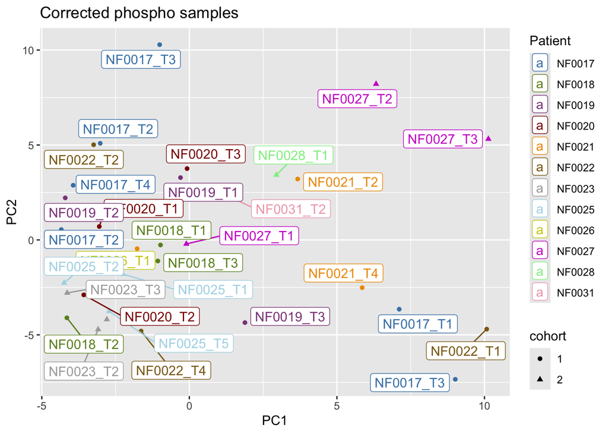

```r
 ppcs<-prcomp(t(cbmat))

 pplot<-ppcs$x|>
  as.data.frame()|>
  dplyr::select(PC1,PC2)|>
  tibble::rownames_to_column('fname')|>
   left_join(rbind(pfnames1,pfnames2))|>
  left_join(meta)|>
    dplyr::select(PC1,PC2,Specimen,Patient,cohort)|>
    mutate(cohort=as.factor(cohort))|>
  distinct()|>
  ggplot(aes(x=PC1,y=PC2,label=Specimen,col=Patient,shape=cohort))+
  geom_point()+ggrepel::geom_label_repel()+ggtitle("Corrected phospho samples")+
  scale_color_manual(values=pcols)
 pplot
```

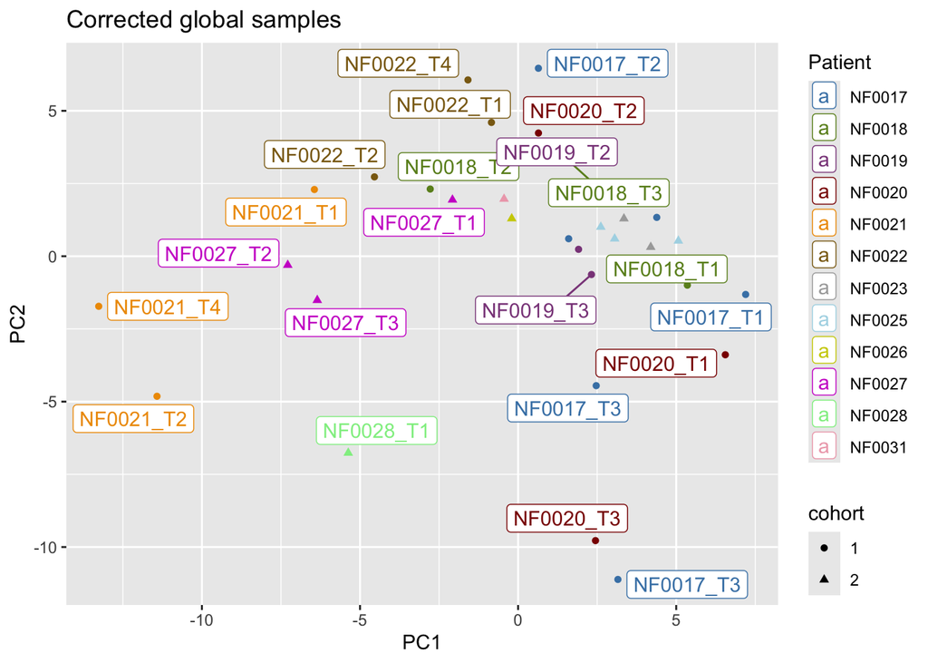

```r
 gpcs<-prcomp(t(cgmat))
 gplot<-gpcs$x|>
  as.data.frame()|>
  dplyr::select(PC1,PC2)|>
  tibble::rownames_to_column('fname')|>
   left_join(rbind(gfnames1,gfnames2))|>
  left_join(meta)|>
    dplyr::select(PC1,PC2,Specimen,Patient,cohort)|>
    mutate(cohort=as.factor(cohort))|>
  distinct()|>
  ggplot(aes(x=PC1,y=PC2,label=Specimen,col=Patient,shape=cohort))+
  geom_point()+ggrepel::geom_label_repel()+ggtitle("Corrected global samples")+
  scale_color_manual(values=pcols)
 gplot
```

## Upload batch-corrected data to synapse

Now we can reformat the batch-corrected data and upload to syanps

```r
pc_long <- cbmat |>
  as.data.frame() |>
    tibble::rownames_to_column('site') |>
    pivot_longer(-site,names_to = 'fname',values_to = 'correctedAbundance') |>
  left_join(rbind(pfnames1,pfnames2)) |>
  left_join(meta) |>
  distinct()
gc_long <- cgmat |>
   as.data.frame() |>
    tibble::rownames_to_column('Gene') |>
    pivot_longer(-Gene,names_to = 'fname',values_to = 'correctedAbundance') |>
  left_join(rbind(gfnames1,gfnames2)) |>
  left_join(meta) |>
  distinct()
readr::write_csv(pc_long,file='batch12_correctedPhospho.csv')
readr::write_csv(gc_long,file='batch12_correctedGlobal.csv')

syn$store(File('batch12_correctedPhospho.csv',parentId='syn70078365'))
```

```
## File(modifiedOn='2025-10-07T16:10:24.600Z', synapseStore=True, etag='4ea27841-ef8e-4944-9a83-56d5ece5a31b', createdBy='1418096', path='batch12_correctedPhospho.csv', files=['batch12_correctedPhospho.csv'], id='syn70078415', parentId='syn70078365', concreteType='org.sagebionetworks.repo.model.File…
```

```r
syn$store(File('batch12_correctedGlobal.csv',parentId='syn70078365'))
```

```
## File(synapseStore=True, createdBy='1418096', files=['batch12_correctedGlobal.csv'], name='batch12_correctedGlobal.csv', _file_handle={'id': '163984320', 'etag': 'f63e08df-542c-4642-a0f8-5314cda43a43', 'createdBy': '1418096', 'createdOn': '2025-10-07T15:56:29.000Z', 'modifiedOn': '2025-10-07T15:56…
```